# Hyderabad_Restaurants

## Exploring best places to Hangout in Hyderabad, India

- Introduction
- Data Collection
- Data Cleaning
- Methodolgy
- Analysis
- Results and Discussion
- Conclusion

### Introduction

The Goal is to identify the best restaurants, cafe etc., in `Hyderabad based on their ratings and average prices.` We will be getting information about the places in Hyderabad using `Four Square API` for getting places near-by and `ZOMATO API` for getting the ratings and average prices to help visitors for selecting the best restaurant that suits them.

For Example if a user is visiting a city they start looking for places to visit during stay.They mainly look for places based on the venue ratings across all venues and the average prices such that the location fits in their budget.

Here we will be `Identifying the places that are fit for various individuals` based on the information obtained from the two APIs and Data Science.

### Data Collection

We will have a look at Hyderabad Map. As most of the people will be staying at places near by ameerpet.In this use case i will be concentrating on the places near by **Ameerpet(17.4375° N, 78.4482° E)** So that a lot people will be getting benefitted.

We will fetch data from 2 APIs:

### Hyderabad

Hyderabad is the best place to explore and also it is one of the best place expecially when it comes to varieties of Food(Restaurants,hotels etc..,)

Here we are restricting to the Ameerpet(one of the place with huge crowd).

```python
# Importing all the required libraries

import pandas as pd
import numpy as np

import matplotlib.pyplot as plt

from pandas.io.json import json_normalize
import requests

# !conda install -c conda-forge beautifulsoup4 --yes # installing bs4 package # uncomment for the 1st time to install the package
# !conda install -c conda-forge html5lib --yes # installing html5lib package alrady available in envt
# !conda install -c conda-forge lxml --yes # lxml’s HTML parser can retrieve html pages
# !conda install -c conda-forge geocoder --yes
# !conda install -c conda-forge folium=0.5.0 --yes # uncomment this line if it is loaded once

# !conda install -c conda-forge geopy --yes
# !conda install tensorflow-gpu keras
import folium # map rendering library
from geopy.geocoders import Nominatim
from bs4 import BeautifulSoup
import requests
from sklearn.cluster import KMeans

import matplotlib.cm as cm
import matplotlib.colors as colors

import requests
```

```python
Hyd_latitude = 17.4375
Hyd_longitude = 78.4482
print('geo coordinates of Hyderabad India are {} {} '.format(Hyd_latitude,Hyd_longitude))
```

```
geo coordinates of Hyderabad India are 17.4375 78.4482
```

```python
hyd_map = folium.Map(location = [Hyd_latitude,Hyd_longitude],zoom_start=10)
folium.Marker([Hyd_latitude,Hyd_longitude]).add_to(hyd_map)
hyd_map.save('Hyderabad_Map.html')
hyd_map
```

[interactive chart not shown]

### FourSquare API

we will start by fetching all the venues in Hyderabad upto a range of 4Kms using FourSquare API. Here we are using **`Explore`** API in FourSquare to get the details of the near by places

```python
FOURSQUARE_CLIENT_ID = 'CXST52NKZIR04JODAXOQX1P3M0U43KBWUEDQLNMQ2B4RC2TL'
FOURSQUARE_CLIENT_SECRET = '42DG3PTXLR242ITY13S0XLMLSMFGKZZWQWVX25F5UCES4CMY'
RADIUS = 4000 # 4 Km
NO_OF_VENUES = 100
VERSION = '20200108' # Current date
```

```python
## get_category_type -  to get teh correct category if each venue

def get_category_type(row):
    try :
        categories_list = row['categories']
    except :
        categories_list = row['venue.categories']
    if len(categories_list) == 0:
        return None
    else:
        return categories_list[0]['name']
```

The API will be called number of time till we get 100 venues, we will fetch all the venues by iteratively calling API and also increasing the OFFSET each time.

- FOURSQUARE API need client_id, client_secret to access the API (a developer account need to be created).
- Setting the radius as 4 Kms
- Version needs to be mentioned for retrieving the latest data

```python
pd.set_option('display.max_rows',None)
offset = 0
total_venues = 0
foursquare_venues = pd.DataFrame(columns =['name','categories','lat','lng'])
LIMIT = 10
while(total_venues<10): # changing limit to 10
    url = ('https://api.foursquare.com/v2/venues/explore?client_id={}&client_secret={}&v={}&ll={},{}&radius={}&limit={}&offset={}&LIMIT = {}').format(
                       FOURSQUARE_CLIENT_ID,FOURSQUARE_CLIENT_SECRET,
                       VERSION,
                       Hyd_latitude,Hyd_longitude,
                       RADIUS,
                       NO_OF_VENUES,
                       offset,
                       LIMIT)
    result = requests.get(url).json()
    venues_fetched = len(result['response']['groups'][0]['items'])

    total_venues = total_venues + venues_fetched
    print("{} venues fetched in {} Km".format(venues_fetched,RADIUS/1000))

    venues = result['response']['groups'][0]['items']
    venues = json_normalize(venues)

    filtered_cols = ['venue.name','venue.categories','venue.location.lat','venue.location.lng'] # filter columns
    venues = venues.loc[:,filtered_cols]
    venues['venue.categories'] = venues.apply(get_category_type,axis =1) # filter category of row
    # cleaning the columns
    venues.columns = [col.split('.')[-1] for col in venues.columns]
    foursquare_venues = pd.concat([foursquare_venues,venues],axis = 0,sort = False)
    #print()
    if(venues_fetched < 100):
        break
    else :
        offset = offset + 100

foursquare_venues = foursquare_venues.reset_index(drop=True)
print("Total {} venues fetched".format(total_venues))
```

```
100 venues fetched in 4.0 Km
Total 100 venues fetched
```

```python
# result
```

```python
foursquare_venues
```

|  | name | categories | lat | lng |
| --- | --- | --- | --- | --- |
| 0 | Mekong | Chinese Restaurant | 17.437151 | 78.454301 |
| 1 | Kakatiya Deluxe Mess | Diner | 17.433435 | 78.447090 |
| 2 | Kebabs & Kurries | Indian Restaurant | 17.432374 | 78.457585 |
| 3 | 10 Downing Street | Pub | 17.435868 | 78.457443 |
| 4 | ITC Kakatiya | Hotel | 17.432514 | 78.457353 |
| 5 | Naturals Ice Cream | Ice Cream Shop | 17.428536 | 78.439620 |
| 6 | Minerva Coffee Shop | Indian Restaurant | 17.428839 | 78.455573 |
| 7 | Vivanta by Taj | Hotel | 17.443498 | 78.460556 |
| 8 | Meridian Resturant | Fast Food Restaurant | 17.427355 | 78.452159 |
| 9 | Hotel Green Park | Hotel | 17.436276 | 78.453892 |
| 10 | Lamakaan | Performing Arts Venue | 17.421017 | 78.447474 |
| 11 | Lifestyle | Clothing Store | 17.436356 | 78.456529 |
| 12 | Park Hyatt Hyderabad | Hotel | 17.424764 | 78.429600 |
| 13 | Southern Mirchi | South Indian Restaurant | 17.426419 | 78.448560 |
| 14 | Kritunga Restaurant | Indian Restaurant | 17.438083 | 78.442897 |
| 15 | GVK One | Shopping Mall | 17.419411 | 78.448069 |
| 16 | Chinese Pavilion | Asian Restaurant | 17.423456 | 78.448695 |
| 17 | Big Byte | Bakery | 17.430177 | 78.438352 |
| 18 | Blue Fox | Indian Restaurant | 17.437054 | 78.445912 |
| 19 | Hard Rock Cafe Hyderabad | American Restaurant | 17.419400 | 78.448533 |
| 20 | Club 8 | Bar | 17.436323 | 78.457080 |
| 21 | Aqua | Hotel Bar | 17.423612 | 78.462541 |
| 22 | PVR Cinemas | Multiplex | 17.426516 | 78.453261 |
| 23 | Himalayas | Bookstore | 17.426359 | 78.451211 |
| 24 | Chutney's | Vegetarian / Vegan Restaurant | 17.426219 | 78.447569 |
| 25 | Starbucks | Coffee Shop | 17.419419 | 78.448134 |
| 26 | Q-Mart | Department Store | 17.426681 | 78.438616 |
| 27 | Guilt Trip | Deli / Bodega | 17.417401 | 78.443219 |
| 28 | INOX Movies | Multiplex | 17.419391 | 78.448119 |
| 29 | Marigold | Hotel | 17.437116 | 78.454506 |

[output cut: 70 more lines]

```python
# foursquare_venues
```

### Zomato API

The Zomato API allows using its Search API to search for a given venues based on search filters such as query,lat,lng etc.., Need to create a Zomato Developer account to access the content from Zomato through API

Using the results(name , lat,lng) obtained from FOURSQUARE API for getting more details about the venue from Zomato API

- Query will be name of the venue
- Start defines from what offset we want to start , so set offset = 0
- Count defines the num of restaurants we want to fetch. As we have the exact location coordinates,we will fetch only per call
- Providing longitude and latitude values
- we will set the sorting crieteria as real_distance for getting the venue we are searching based on location coordinates

```python
# Zomato ID: 604b38157676fff2a2bc8bd4b37cbc2d laxman kishore ID
headers = {'user-key': 'b3a1c26ed20422bfaae7ada558744e1f'} # mentors
venues_information = []
for index , row in foursquare_venues.iterrows():
    print("Fetching the {} th venue details : {} ".format(index+1,row['name']))
    venue=[]
    url = ('https://developers.zomato.com/api/v2.1/search?q={}&start=0&count=1&lat={}&lon={}&sort=real_distance').format(
            row['name'], row['lat'], row['lng'])

    result = requests.get(url,headers=headers).json()
    #print(result['restaurants'][0]['restaurant']['name'])
    if(len(result['restaurants'])>0):
        venue.append(result['restaurants'][0]['restaurant']['name'])
        venue.append(result['restaurants'][0]['restaurant']['location']['latitude'])
        venue.append(result['restaurants'][0]['restaurant']['location']['longitude'])
        venue.append(result['restaurants'][0]['restaurant']['average_cost_for_two'])
        venue.append(result['restaurants'][0]['restaurant']['price_range'])
        venue.append(result['restaurants'][0]['restaurant']['user_rating']['aggregate_rating'])
        venue.append(result['restaurants'][0]['restaurant']['location']['address'])
        venues_information.append(venue)
    else :
        venues_information.append(np.zeros(6))

zomato_venues = pd.DataFrame(venues_information,columns=['venue','latitude','longitude','price_for_two','price_range','rating','address'])
zomato_venues.head()
```

```
Fetching the 1 th venue details : Mekong
Fetching the 2 th venue details : Kakatiya Deluxe Mess
Fetching the 3 th venue details : Kebabs & Kurries
Fetching the 4 th venue details : 10 Downing Street
Fetching the 5 th venue details : ITC Kakatiya
Fetching the 6 th venue details : Naturals Ice Cream
Fetching the 7 th venue details : Minerva Coffee Shop
Fetching the 8 th venue details : Vivanta by Taj
Fetching the 9 th venue details : Meridian Resturant
Fetching the 10 th venue details : Hotel Green Park
Fetching the 11 th venue details : Lamakaan
Fetching the 12 th venue details : Lifestyle
Fetching the 13 th venue details : Park Hyatt Hyderabad
Fetching the 14 th venue details : Southern Mirchi
Fetching the 15 th venue details : Kritunga Restaurant
Fetching the 16 th venue details : GVK One
Fetching the 17 th venue details : Chinese Pavilion
Fetching the 18 th venue details : Big Byte
Fetching the 19 th venue details : Blue Fox
Fetching the 20 th venue details : Hard Rock Cafe Hyderabad
Fetching the 21 th venue details : Club 8
Fetching the 22 th venue details : Aqua
Fetching the 23 th venue details : PVR Cinemas
Fetching the 24 th venue details : Himalayas
Fetching the 25 th venue details : Chutney's
Fetching the 26 th venue details : Starbucks
Fetching the 27 th venue details : Q-Mart
Fetching the 28 th venue details : Guilt Trip
Fetching the 29 th venue details : INOX Movies
Fetching the 30 th venue details : Marigold
Fetching the 31 th venue details : water
Fetching the 32 th venue details : Deccan Pavilion
Fetching the 33 th venue details : Poorna Tiffin Center
Fetching the 34 th venue details : Necklace Road
Fetching the 35 th venue details : Crossword
Fetching the 36 th venue details : Cream Stone Concepts
Fetching the 37 th venue details : Paradise Restaurant
Fetching the 38 th venue details : Vac's
Fetching the 39 th venue details : Sahib Sindh Sultan
Fetching the 40 th venue details : Tre Forni
```

[output cut: 45 more lines]

```
Fetching the 86 th venue details : Chambers @ Taj Krishna
Fetching the 87 th venue details : The Pasta Bar Veneto
Fetching the 88 th venue details : Ohri's
Fetching the 89 th venue details : Deja Vu
Fetching the 90 th venue details : Khan Saab
Fetching the 91 th venue details : Shoppers Stop
Fetching the 92 th venue details : Subway
Fetching the 93 th venue details : Hyderabad Central
Fetching the 94 th venue details : Coco's Restaurant
Fetching the 95 th venue details : Oh! Calcutta.
Fetching the 96 th venue details : Shree Jaganath Temple
Fetching the 97 th venue details : Syala Drive In
Fetching the 98 th venue details : Blue Fox
Fetching the 99 th venue details : KFC Central
Fetching the 100 th venue details : Beenz
```

|  | venue | latitude | longitude | price_for_two | price_range | rating | address |
| --- | --- | --- | --- | --- | --- | --- | --- |
| 0 | Mekong - Marigold Hotel | 17.4364550525 | 78.4542670101 | 3000.0 | 4.0 | 4.6 | Green Lands, Begumpet, Hyderabad |
| 1 | Hyderabad Street Kitchen | 17.4335190000 | 78.4468990000 | 700.0 | 2.0 | 3.2 | 6-3-793, Officers Colony, Punjagutta, Kakatiya... |
| 2 | Deccan Pavilion - ITC Kakatiya | 17.4324198460 | 78.4563235939 | 2600.0 | 4.0 | 4.2 | ITC Kakatiya, 6 3 1187, Begumpet, Hyderabad |
| 3 | 10 Downing Street | 17.4358981577 | 78.4574236348 | 1800.0 | 3.0 | 4.1 | 10, Ground Floor, My Home Tycoon, Begumpet, Hy... |
| 4 | Dakshin - ITC Kakatiya | 17.4324185665 | 78.4563242644 | 3400.0 | 4.0 | 4.3 | ITC Kakatiya, 6 3 1187, Begumpet, Hyderabad |

```python
# url = ('https://developers.zomato.com/api/v2.1/search?q={}&start=0&count=1&sort=real_distance').format(
#            'Kebabs & Kurries')
# result = requests.get(url,headers=headers).json()
```

```python
result
```

[output not shown]

[output cut: 163 more lines]

[output not shown]

```python
zomato_venues
```

|  | venue | latitude | longitude | price_for_two | price_range | rating | address |
| --- | --- | --- | --- | --- | --- | --- | --- |
| 0 | Mekong - Marigold Hotel | 17.4364550525 | 78.4542670101 | 3000.0 | 4.0 | 4.6 | Green Lands, Begumpet, Hyderabad |
| 1 | Hyderabad Street Kitchen | 17.4335190000 | 78.4468990000 | 700.0 | 2.0 | 3.2 | 6-3-793, Officers Colony, Punjagutta, Kakatiya... |
| 2 | Deccan Pavilion - ITC Kakatiya | 17.4324198460 | 78.4563235939 | 2600.0 | 4.0 | 4.2 | ITC Kakatiya, 6 3 1187, Begumpet, Hyderabad |
| 3 | 10 Downing Street | 17.4358981577 | 78.4574236348 | 1800.0 | 3.0 | 4.1 | 10, Ground Floor, My Home Tycoon, Begumpet, Hy... |
| 4 | Dakshin - ITC Kakatiya | 17.4324185665 | 78.4563242644 | 3400.0 | 4.0 | 4.3 | ITC Kakatiya, 6 3 1187, Begumpet, Hyderabad |
| 5 | Natural Ice Cream | 17.4285918352 | 78.4396097437 | 200.0 | 1.0 | 4.6 | G 3, Raghavendra Grand Residency, Opposite Rat... |
| 6 | Minerva Coffee Shop | 17.4287802467 | 78.4559651837 | 800.0 | 2.0 | 3.9 | Ground Floor, Amrutha Mall, Opposite GRT Jewel... |
| 7 | The Grill - Vivanta By Taj | 17.4437175595 | 78.4608565271 | 2200.0 | 4.0 | 3.9 | Vivanta By Taj, 1-10-147 & 148, Mayuri Marg, B... |
| 8 | Meridian Cafe & Restaurant | 17.4274290000 | 78.4522630000 | 600.0 | 2.0 | 4.5 | 6-3-697/1, Officers Colony, Panjagutta Cross R... |
| 9 | Tulips - Hotel GreenPark | 17.4359365423 | 78.4538727254 | 1400.0 | 3.0 | 3.9 | Hotel Green Park, Begumpet, Hyderabad |
| 10 | Lamakaan | 17.4211559818 | 78.4473060071 | 200.0 | 1.0 | 4.6 | Near GVK One, Road 5, Banjara Hills, Hyderabad |
| 11 | Madhura | 17.4359474179 | 78.4566045552 | 600.0 | 2.0 | 3.6 | Block 1, Near Lifestyle Building, Begumpet, Hy... |
| 12 | Tre-Forni Restaurant and Bar - Park Hyatt | 17.4243737969 | 78.4297083691 | 3000.0 | 4.0 | 4.5 | Park Hyatt Hyderabad, Road 2, Banjara Hills, H... |
| 13 | Southern Mirchi | 17.4264153319 | 78.4486343712 | 800.0 | 2.0 | 3.7 | Plot 76, Nagarjuna Hills, Panjagutta, Hyderabad |
| 14 | Kritunga Restaurant | 17.4380726286 | 78.4428166598 | 700.0 | 2.0 | 3.8 | 8-3-214/2/41, Opposite Maitrivanam, West Srini... |
| 15 | WOK Republic | 17.4196790116 | 78.4480416030 | 550.0 | 2.0 | 0 | GVK One Mall, Counter 9, 3rd Floor, Food Court... |
| 16 | Chinese Pavilion | 17.4235180857 | 78.4487527236 | 1000.0 | 3.0 | 4.2 | Vengal Rao Park, Road 1, Banjara Hills, Hyderabad |
| 17 | Big Byte | 17.4302408294 | 78.4383672103 | 450.0 | 1.0 | 4.0 | 8-3-978/3, Road 1, Dwarakapuri, Srinagar Colon... |
| 18 | Blue Fox | 17.4374575228 | 78.4459752962 | 1000.0 | 3.0 | 3.6 | Plot No 3, Regency Plaza, Behind HUDA Mythriva... |
| 19 | Pizza Hut | 17.4193479152 | 78.4484747797 | 600.0 | 2.0 | 2.8 | 3rd Floor, GVK One Mall, Road 1, Banjara Hills... |
| 20 | Club8 | 17.4363437376 | 78.4573324397 | 800.0 | 2.0 | 3.7 | 1st Floor, Lifestyle Building, Begumpet, Hyder... |
| 21 | Aqua - The Park | 17.4230529609 | 78.4626710415 | 2500.0 | 4.0 | 4.4 | The Park Hotel, 22, Raj Bhavan Road, Somajigud... |
| 22 | Eaters DEN | 17.4257704371 | 78.4530345351 | 350.0 | 1.0 | 3.4 | 6-3-672/D, Beside PVR Cinemas, Panjagutta, Hyd... |
| 23 | Rocket Fuel Cafe | 17.4261840000 | 78.4569780000 | 700.0 | 2.0 | 4.1 | 6-3-902, 1st Floor, Raj Bhavan Road, Somajigud... |
| 24 | Lassi Corner | 17.4297060000 | 78.4491830000 | 300.0 | 1.0 | 0 | 1-632/205, Opposite Narayana Junior College, B... |
| 25 | Starbucks Coffee | 17.4194921901 | 78.4483829141 | 700.0 | 2.0 | 4.3 | Ground Floor GVK 1, Road 1, Banjara Hills, Hyd... |
| 26 | Vanilla & Co. | 17.4268046349 | 78.4385834634 | 300.0 | 1.0 | 3.2 | Second Floor, Q Mart, Road 3, Opposite TV 9, B... |
| 27 | Guilt Trip | 17.4230721545 | 78.4605933353 | 800.0 | 2.0 | 4.4 | Opposite Standard Chartered Bank, Raj Bhavan R... |
| 28 | 0 | 0 | 0 | 0.0 | 0.0 | 0 | None |
| 29 | Saffron Soul - Marigold Hotel | 17.4364848004 | 78.4542837739 | 1500.0 | 3.0 | 4.2 | Green Lands, Begumpet, Hyderabad |

[output cut: 70 more lines]

## Data Cleaning

The data from various sources might not always align.So it is important to combine the retrieved data properly

We will plot the 2 data points on the map. Then will try to combine data points that have their latitude and longitude values close to each other.We will also ensure that mismatched venues are removed from the final dataset of venues before starting Analysis.

```python
## FourSquare  DATA on MAP
hyd_map = folium.Map(location = [Hyd_latitude,Hyd_longitude],zoom_start =10)

for name,latitude,longitude in zip(foursquare_venues['name'],foursquare_venues['lat'],foursquare_venues['lng']):
    label = '{}'.format(name)
    label = folium.Popup(label,parse_html = True)
    folium.CircleMarker(
                        [latitude,longitude],
                        radius = 5,
                        popup=label,
    color = 'green',
    fill=True,
    fill_color = "#3186cc",
    fill_opacity = 0.7,
    parse_html = False).add_to(hyd_map)
hyd_map.save("Venues_by_FourSquare.html")
hyd_map
```

[interactive chart not shown]

```python
zomato_venues['latitude'] = pd.to_numeric(zomato_venues['latitude'])
zomato_venues['longitude'] = pd.to_numeric(zomato_venues['longitude'])
```

```python
## Zomato Data on MAP
hyd_map = folium.Map(location = [Hyd_latitude,Hyd_longitude],zoom_start =10)

for venue,address,latitude,longitude in zip(zomato_venues['venue'],zomato_venues['address'],zomato_venues['latitude'],zomato_venues['longitude']):
    label = '{},{}'.format(venue,address)
    label = folium.Popup(label,parse_html = True)
#     folium.CircleMarker(
#                         [latitude,longitude],
#                         radius = 5,
#                         popup=label,
#                         color = 'red',
#                         fill=True,
#                         fill_color = "#cc3535",
#                         fill_opacity = 0.7
#     ).add_to(hyd_map)
    folium.CircleMarker(
                        [latitude,longitude],
                        radius = 5,
                        popup=label,
    color = 'red',
    fill=True,
    fill_color = "#cc3535",
    fill_opacity = 0.7,
    parse_html = False).add_to(hyd_map)

hyd_map.save("Venues_by_Zomato.html")
hyd_map
```

[interactive chart not shown]

```python
foursquare_venues['lat'] = foursquare_venues['lat'].apply(lambda lat : round(float(lat),4))
foursquare_venues['lng'] = foursquare_venues['lng'].apply(lambda lng : round(float(lng),4))
zomato_venues['latitude'] = zomato_venues['latitude'].apply(lambda lat : round(float(lat),4))
zomato_venues['longitude'] = zomato_venues['longitude'].apply(lambda lng : round(float(lng),4))
```

```python
dataset = pd.concat([foursquare_venues,zomato_venues],axis=1)
dataset['lat_diff'] = dataset['latitude'] - dataset['lat']
dataset['lng_diff'] = dataset['longitude']- dataset['lng']
```

```python
selected_venues = dataset[(abs(dataset['lat_diff'])<=0.0004)& (abs(dataset['lng_diff'])<=0.0004)].reset_index(drop=True)
selected_venues
```

|  | name | categories | lat | lng | venue | latitude | longitude | price_for_two | price_range | rating | address | lat_diff | lng_diff |
| --- | --- | --- | --- | --- | --- | --- | --- | --- | --- | --- | --- | --- | --- |
| 0 | Kakatiya Deluxe Mess | Diner | 17.4334 | 78.4471 | Hyderabad Street Kitchen | 17.4335 | 78.4469 | 700.0 | 2.0 | 3.2 | 6-3-793, Officers Colony, Punjagutta, Kakatiya... | 0.0001 | -0.0002 |
| 1 | 10 Downing Street | Pub | 17.4359 | 78.4574 | 10 Downing Street | 17.4359 | 78.4574 | 1800.0 | 3.0 | 4.1 | 10, Ground Floor, My Home Tycoon, Begumpet, Hy... | 0.0000 | 0.0000 |
| 2 | Naturals Ice Cream | Ice Cream Shop | 17.4285 | 78.4396 | Natural Ice Cream | 17.4286 | 78.4396 | 200.0 | 1.0 | 4.6 | G 3, Raghavendra Grand Residency, Opposite Rat... | 0.0001 | 0.0000 |
| 3 | Minerva Coffee Shop | Indian Restaurant | 17.4288 | 78.4556 | Minerva Coffee Shop | 17.4288 | 78.4560 | 800.0 | 2.0 | 3.9 | Ground Floor, Amrutha Mall, Opposite GRT Jewel... | 0.0000 | 0.0004 |
| 4 | Vivanta by Taj | Hotel | 17.4435 | 78.4606 | The Grill - Vivanta By Taj | 17.4437 | 78.4609 | 2200.0 | 4.0 | 3.9 | Vivanta By Taj, 1-10-147 & 148, Mayuri Marg, B... | 0.0002 | 0.0003 |
| 5 | Meridian Resturant | Fast Food Restaurant | 17.4274 | 78.4522 | Meridian Cafe & Restaurant | 17.4274 | 78.4523 | 600.0 | 2.0 | 4.5 | 6-3-697/1, Officers Colony, Panjagutta Cross R... | 0.0000 | 0.0001 |
| 6 | Hotel Green Park | Hotel | 17.4363 | 78.4539 | Tulips - Hotel GreenPark | 17.4359 | 78.4539 | 1400.0 | 3.0 | 3.9 | Hotel Green Park, Begumpet, Hyderabad | -0.0004 | 0.0000 |
| 7 | Lamakaan | Performing Arts Venue | 17.4210 | 78.4475 | Lamakaan | 17.4212 | 78.4473 | 200.0 | 1.0 | 4.6 | Near GVK One, Road 5, Banjara Hills, Hyderabad | 0.0002 | -0.0002 |
| 8 | Southern Mirchi | South Indian Restaurant | 17.4264 | 78.4486 | Southern Mirchi | 17.4264 | 78.4486 | 800.0 | 2.0 | 3.7 | Plot 76, Nagarjuna Hills, Panjagutta, Hyderabad | 0.0000 | 0.0000 |
| 9 | Kritunga Restaurant | Indian Restaurant | 17.4381 | 78.4429 | Kritunga Restaurant | 17.4381 | 78.4428 | 700.0 | 2.0 | 3.8 | 8-3-214/2/41, Opposite Maitrivanam, West Srini... | 0.0000 | -0.0001 |
| 10 | GVK One | Shopping Mall | 17.4194 | 78.4481 | WOK Republic | 17.4197 | 78.4480 | 550.0 | 2.0 | 0 | GVK One Mall, Counter 9, 3rd Floor, Food Court... | 0.0003 | -0.0001 |
| 11 | Chinese Pavilion | Asian Restaurant | 17.4235 | 78.4487 | Chinese Pavilion | 17.4235 | 78.4488 | 1000.0 | 3.0 | 4.2 | Vengal Rao Park, Road 1, Banjara Hills, Hyderabad | 0.0000 | 0.0001 |
| 12 | Big Byte | Bakery | 17.4302 | 78.4384 | Big Byte | 17.4302 | 78.4384 | 450.0 | 1.0 | 4.0 | 8-3-978/3, Road 1, Dwarakapuri, Srinagar Colon... | 0.0000 | 0.0000 |
| 13 | Blue Fox | Indian Restaurant | 17.4371 | 78.4459 | Blue Fox | 17.4375 | 78.4460 | 1000.0 | 3.0 | 3.6 | Plot No 3, Regency Plaza, Behind HUDA Mythriva... | 0.0004 | 0.0001 |
| 14 | Hard Rock Cafe Hyderabad | American Restaurant | 17.4194 | 78.4485 | Pizza Hut | 17.4193 | 78.4485 | 600.0 | 2.0 | 2.8 | 3rd Floor, GVK One Mall, Road 1, Banjara Hills... | -0.0001 | 0.0000 |
| 15 | Club 8 | Bar | 17.4363 | 78.4571 | Club8 | 17.4363 | 78.4573 | 800.0 | 2.0 | 3.7 | 1st Floor, Lifestyle Building, Begumpet, Hyder... | 0.0000 | 0.0002 |
| 16 | Starbucks | Coffee Shop | 17.4194 | 78.4481 | Starbucks Coffee | 17.4195 | 78.4484 | 700.0 | 2.0 | 4.3 | Ground Floor GVK 1, Road 1, Banjara Hills, Hyd... | 0.0001 | 0.0003 |
| 17 | Q-Mart | Department Store | 17.4267 | 78.4386 | Vanilla & Co. | 17.4268 | 78.4386 | 300.0 | 1.0 | 3.2 | Second Floor, Q Mart, Road 3, Opposite TV 9, B... | 0.0001 | 0.0000 |
| 18 | Cream Stone Concepts | Ice Cream Shop | 17.4248 | 78.4220 | Cream Stone | 17.4249 | 78.4219 | 350.0 | 1.0 | 4.4 | Ground Floor, Beside Talwar Hyundai, Road 2, ... | 0.0001 | -0.0001 |
| 19 | Paradise Restaurant | Hyderabadi Restaurant | 17.4445 | 78.4624 | Paradise Biryani | 17.4445 | 78.4625 | 800.0 | 2.0 | 4.4 | Near Saptagiri Towers, Mayur Marg, Begumpet, H... | 0.0000 | 0.0001 |
| 20 | Sahib Sindh Sultan | Indian Restaurant | 17.4148 | 78.4491 | Journey 1853 | 17.4152 | 78.4489 | 1800.0 | 3.0 | 4.2 | 5th Floor, City Center Mall, Road 1, Banjara H... | 0.0004 | -0.0002 |
| 21 | The Roastery Coffee House | Café | 17.4234 | 78.4316 | The Roastery Coffee House | 17.4234 | 78.4316 | 800.0 | 2.0 | 4.8 | 8/2/287/12, House 418, Road 14, Banjara Hills,... | 0.0000 | 0.0000 |
| 22 | WOFL | Breakfast Spot | 17.4249 | 78.4381 | WOFL | 17.4250 | 78.4383 | 500.0 | 2.0 | 4.0 | Door 8-2-334/N/3, Plot 3, Banjara Hills, Hyder... | 0.0001 | 0.0002 |
| 23 | KFC | Fast Food Restaurant | 17.4235 | 78.4282 | KFC | 17.4233 | 78.4279 | 450.0 | 1.0 | 3.8 | Ground Floor, Cinemax Building, RK Cineplex, R... | -0.0002 | -0.0003 |
| 24 | Kismet | Nightclub | 17.4235 | 78.4626 | Kismet - The Park | 17.4231 | 78.4627 | 3000.0 | 4.0 | 4.2 | The Park Hotel, 22, 1st Floor, Raj Bhavan Road... | -0.0004 | 0.0001 |
| 25 | Santosh Dhaba | Vegetarian / Vegan Restaurant | 17.4394 | 78.4483 | Santosh Dhaba | 17.4395 | 78.4482 | 450.0 | 1.0 | 3.9 | 7-1-404/1, Satyam Theatre Road, Sanabai Temple... | 0.0001 | -0.0001 |
| 26 | Ohris de thali | Vegetarian / Vegan Restaurant | 17.4357 | 78.4576 | Ohri's Cake Shop | 17.4357 | 78.4578 | 400.0 | 1.0 | 3.1 | Door 6-3-1192/1/1, White House G 19 - 24, Grou... | 0.0000 | 0.0002 |
| 27 | Barbeque Nation | BBQ Joint | 17.4150 | 78.4499 | UBQ by Barbeque Nation | 17.4152 | 78.4502 | 400.0 | 1.0 | 3.1 | 6-3-249/5/1, ANR Center, 2nd Floor, Road 1, Ba... | 0.0002 | 0.0003 |
| 28 | Chopsticks | Chinese Restaurant | 17.4299 | 78.4457 | Chop Sticks | 17.4299 | 78.4455 | 300.0 | 1.0 | 4.1 | 8-3-960/9, Srinagar Colony, Hyderabad | 0.0000 | -0.0002 |
| 29 | The Lounge (CCD) | Café | 17.4148 | 78.4480 | Cafe Coffee Day - The Lounge | 17.4147 | 78.4481 | 600.0 | 2.0 | 3.4 | Building 5, Ground Floor, Road 10, Near Rainbo... | -0.0001 | 0.0001 |
| 30 | Mercure Hyderabad KCP | Hotel | 17.4177 | 78.4569 | IQ Lounge Bar - Mercure Hyderabad KCP | 17.4178 | 78.4570 | 800.0 | 2.0 | 3.6 | 6-3-551, Mercure KCP, Erramanjil, Near Banjara... | 0.0001 | 0.0001 |
| 31 | Needs Fast Food Joint | Indian Restaurant | 17.4357 | 78.4614 | Jai Hanuman Chat Bhandar | 17.4358 | 78.4614 | 100.0 | 1.0 | 3.1 | Near Sri Rajarajashwari Kirana Store, Uma Naga... | 0.0001 | 0.0000 |
| 32 | Ofen | Bakery | 17.4158 | 78.4430 | Ofen | 17.4155 | 78.4431 | 1000.0 | 3.0 | 4.0 | Road 10, Banjara Hills, Hyderabad | -0.0003 | 0.0001 |
| 33 | Rain Lounge | Nightclub | 17.4256 | 78.4203 | Karma Unplugged Bar | 17.4256 | 78.4203 | 1500.0 | 3.0 | 4.2 | 8th Floor, Shangri La Towers, Road 2, Banjara ... | 0.0000 | 0.0000 |
| 34 | Sarvi | Indian Restaurant | 17.4127 | 78.4497 | Sarvi Restaurant | 17.4129 | 78.4497 | 850.0 | 2.0 | 4.2 | 6-2-626, Opposite Care Hospital, Road 1 & 11, ... | 0.0002 | 0.0000 |
| 35 | Zafraan Exotica | Indian Restaurant | 17.4103 | 78.4373 | Exotica | 17.4103 | 78.4372 | 1800.0 | 3.0 | 4.6 | 5th Floor, 12th Square Building, Road 12, Oppo... | 0.0000 | -0.0001 |
| 36 | Subway | Sandwich Place | 17.4255 | 78.4572 | Subway | 17.4254 | 78.4568 | 350.0 | 1.0 | 2.7 | 6-3-902/A, Ground Floor, Central Plaza Complex... | -0.0001 | -0.0004 |
| 37 | Spice 6 | Bistro | 17.4090 | 78.4506 | Spice 6 - Global Dining | 17.4091 | 78.4507 | 1100.0 | 3.0 | 4.3 | Plot 6-3-247, Lakshmi Nivas, Beside Kusum Show... | 0.0001 | 0.0001 |
| 38 | Karachi Bakery | Bakery | 17.4106 | 78.4498 | Karachi Bakery | 17.4105 | 78.4499 | 450.0 | 1.0 | 4.5 | 6-3-190/1, Khanchand Towers, Road 1, Banjara H... | -0.0001 | 0.0001 |
| 39 | Donut House | Donut Shop | 17.4229 | 78.4620 | Sanjos Donuts | 17.4230 | 78.4619 | 400.0 | 1.0 | 4.2 |  | 0.0001 | -0.0001 |
| 40 | Shoppers Stop | Clothing Store | 17.4452 | 78.4658 | Food Garrage | 17.4453 | 78.4659 | 200.0 | 1.0 | 0 | Alladin Mansion, Shoppers Stop, Begumpet, Hyde... | 0.0001 | 0.0001 |
| 41 | IMAX Screen | Multiplex | 17.4130 | 78.4656 | KFC | 17.4128 | 78.4656 | 500.0 | 2.0 | 3.7 | Imax Road, LIC Division, NTR Gardens, Necklace... | -0.0002 | 0.0000 |
| 42 | Chutneys | Indian Restaurant | 17.4434 | 78.4799 | Chutneys | 17.4431 | 78.4799 | 600.0 | 2.0 | 4.1 | 1-8-303/48/3, S P Road, Secunderabad | -0.0003 | 0.0000 |
| 43 | Roll Call | Indian Restaurant | 17.4262 | 78.4481 | Roll Call | 17.4262 | 78.4481 | 300.0 | 1.0 | 3.6 | Nagarjuna Circle, Panjagutta Flyover, VST Colo... | 0.0000 | 0.0000 |
| 44 | TGI Friday's | American Restaurant | 17.4236 | 78.4276 | TGI Fridays | 17.4235 | 78.4279 | 2200.0 | 4.0 | 4.1 | 1st Floor, Cinemax Building, RK Cineplex, Oppo... | -0.0001 | 0.0003 |
| 45 | Tibbs Frankies | Sandwich Place | 17.4361 | 78.4565 | Tibbs Frankie | 17.4361 | 78.4565 | 200.0 | 1.0 | 4.0 | White House Building, Kundan Bagh Colony, Gree... | 0.0000 | 0.0000 |
| 46 | Bikanervala | Chaat Place | 17.4108 | 78.4498 | Bikanervala | 17.4110 | 78.4499 | 700.0 | 2.0 | 4.2 | 6-3-190/2, Road 1, Banjara Hills, Hyderabad | 0.0002 | 0.0001 |
| 47 | Rajdhani | Rajasthani Restaurant | 17.4265 | 78.4383 | Rajdhani Thali Restaurant | 17.4266 | 78.4384 | 950.0 | 2.0 | 4.1 | Level 1, Uptown Banjara, Road 3, Opposite Dr. ... | 0.0001 | 0.0001 |
| 48 | Beyond Coffee | Café | 17.4294 | 78.4127 | Beyond Coffee | 17.4296 | 78.4128 | 850.0 | 2.0 | 4.0 | Plot 237, Road 36, Jubilee Hills, Hyderabad | 0.0002 | 0.0001 |
| 49 | The Gallery Cafe | Coffee Shop | 17.4162 | 78.4433 | The Gallery Cafe | 17.4161 | 78.4433 | 800.0 | 2.0 | 4.2 | 8-2-585/1/B, Road 10, Banjara Hills, Hyderabad | -0.0001 | 0.0000 |
| 50 | Burger King | Fast Food Restaurant | 17.4187 | 78.4484 | Burger King | 17.4187 | 78.4486 | 500.0 | 2.0 | 4.0 | 3rd Floor, GVK One, Road 1, Banjara Hills, Hyd... | 0.0000 | 0.0002 |
| 51 | Dimmy pan palace | Bakery | 17.4401 | 78.4843 | Dimmy's Pan Palace | 17.4400 | 78.4842 | 400.0 | 1.0 | 4.0 | 1-8-57, PG Road, Secunderabad | -0.0001 | -0.0001 |
| 52 | Paradise Food Court | Indian Restaurant | 17.4121 | 78.4654 | Paradise Biryani | 17.4124 | 78.4653 | 950.0 | 2.0 | 4.2 | NTR Gardens, Near Prasads IMAX, Saifabad, Neck... | 0.0003 | -0.0001 |
| 53 | Ohri's | Lounge | 17.4319 | 78.4651 | Ohri's 1857 | 17.4318 | 78.4651 | 1000.0 | 3.0 | 4.1 | Ohri's Jalavihar, Near Jalvihar Entertainment ... | -0.0001 | 0.0000 |
| 54 | Hyderabad Central | Shopping Mall | 17.4264 | 78.4528 | Subway | 17.4266 | 78.4528 | 350.0 | 1.0 | 2.8 | Ground Floor, Hyderabad Central Mall, Pajagutt... | 0.0002 | 0.0000 |
| 55 | Oh! Calcutta. | Bengali Restaurant | 17.4315 | 78.4563 | Oh! Calcutta | 17.4315 | 78.4565 | 1600.0 | 3.0 | 4.4 | 6-3-1186/1/1, Greenlands Road, Opposite CM Res... | 0.0000 | 0.0002 |
| 56 | Syala Drive In | Chinese Restaurant | 17.4345 | 78.4133 | Rani Gari Tiffins | 17.4345 | 78.4131 | 250.0 | 1.0 | 3.3 | Syala Drive In, Plot 265, Road 10, Beside HDFC... | 0.0000 | -0.0002 |
| 57 | Blue Fox | Asian Restaurant | 17.4236 | 78.4280 | Blue Fox | 17.4234 | 78.4278 | 1400.0 | 3.0 | 3.9 | 1st Floor, Cinemax Building, RK Cineplex, Road... | -0.0002 | -0.0002 |
| 58 | KFC Central | Fast Food Restaurant | 17.4264 | 78.4527 | Subway | 17.4266 | 78.4528 | 350.0 | 1.0 | 2.8 | Ground Floor, Hyderabad Central Mall, Pajagutt... | 0.0002 | 0.0001 |
| 59 | Beenz | Coffee Shop | 17.4317 | 78.4146 | Theory Cafe & Dessert Bar | 17.4318 | 78.4147 | 1100.0 | 3.0 | 4.2 | Plot 178, Street 13, Jubilee Hills, Hyderabad | 0.0001 | 0.0001 |

```python
cols = ['name','lat','lng','lat_diff','lng_diff','price_for_two']
selected_venues['average_price'] =selected_venues['price_for_two']/2
selected_venues = selected_venues.drop(columns=cols)
```

```python
selected_venues.head(5)
```

|  | categories | venue | latitude | longitude | price_range | rating | address | average_price |
| --- | --- | --- | --- | --- | --- | --- | --- | --- |
| 0 | Diner | Hyderabad Street Kitchen | 17.4335 | 78.4469 | 2.0 | 3.2 | 6-3-793, Officers Colony, Punjagutta, Kakatiya... | 350.0 |
| 1 | Pub | 10 Downing Street | 17.4359 | 78.4574 | 3.0 | 4.1 | 10, Ground Floor, My Home Tycoon, Begumpet, Hy... | 900.0 |
| 2 | Ice Cream Shop | Natural Ice Cream | 17.4286 | 78.4396 | 1.0 | 4.6 | G 3, Raghavendra Grand Residency, Opposite Rat... | 100.0 |
| 3 | Indian Restaurant | Minerva Coffee Shop | 17.4288 | 78.4560 | 2.0 | 3.9 | Ground Floor, Amrutha Mall, Opposite GRT Jewel... | 400.0 |
| 4 | Hotel | The Grill - Vivanta By Taj | 17.4437 | 78.4609 | 4.0 | 3.9 | Vivanta By Taj, 1-10-147 & 148, Mayuri Marg, B... | 1100.0 |

```python
selected_venues = selected_venues[selected_venues['rating']!=0]
print("Total venues available :{}".format(selected_venues.shape[0]))
```

```
Total venues available :58
```

## Methodology

1) At first I retrieved the data from FourSquare and Zomato API's. Extracted venue information from Ameerpet upto a distance of 4Km . The lat and longitude values are used to fetch venue rating and price from Zomato.

2) I have explored the data retrieved from 2 API's on the MAP for identifying TOP category types. The data from 2 sources is combined based on the lat and lng values.Make sure that final dataset include ratings and price values for each venue.

3) Have analysed the data that have been created based on ratings and price of each venue. Also places where many venues are located so that visitor can go to one place where he will be having many choice of venues. Also explored places that are highly rated and low rated and plot them.

4) Finally we will cluster the venues based on available information of each venue. Which allows us to recommend the venues and their characteristics.

## Analysis

We have the complete dataset for processing further

We will inspect these venue values based on their rating(ranging form 1 to 5) and average price per person also the price range

### 1) Categories

We have various types of venues the final dataset. we will figure out majority venue categories in the list

```
<BarContainer object of 30 artists>
```

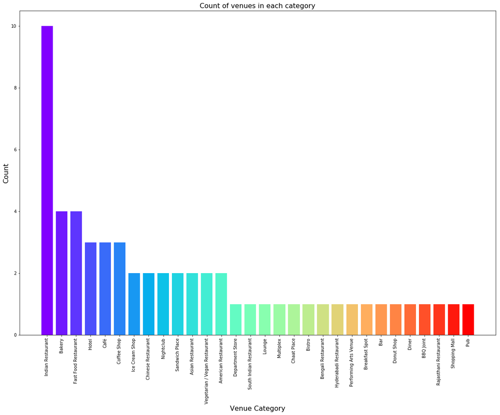

```python
venue_distribution = selected_venues['categories'].value_counts()
colors = cm.rainbow(np.linspace(0,1,len(venue_distribution.index)))
plt.figure(figsize=(20,14))
plt.xticks(rotation = 90)
plt.xlabel("Venue Category",fontsize = 16)
plt.ylabel("Count",fontsize = 16)
plt.title("Count of venues in each category",fontsize=16)
plt.bar(venue_distribution.index,venue_distribution.values,color = colors)
```

we can observe that **"Indian Restaurant and Fast Food Restaurant and Bakery"**

### Rating

Rating of venue is very important only by which visitor will decide whether to visit the venue or not or is it worth to visit. We will observe the average ratings of the venues in the city

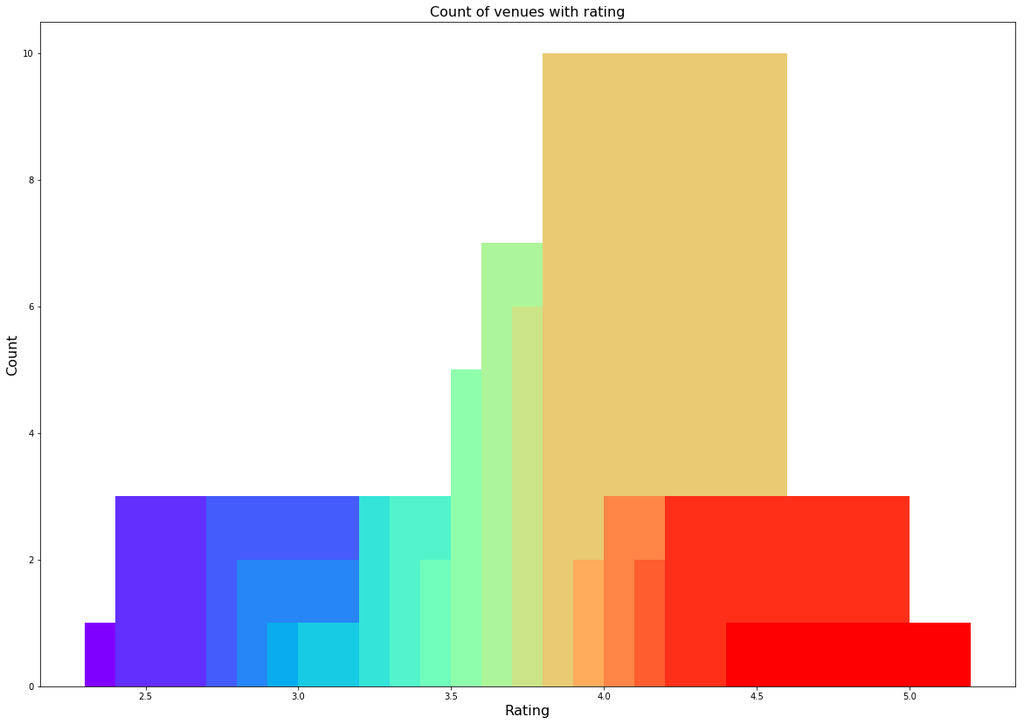

```python
selected_venues['rating']= selected_venues['rating'].astype(float)
rating = selected_venues['rating'].value_counts().sort_index()
plt.figure(figsize = (20,14))
plt.bar(rating.index,rating.values,color = cm.rainbow(np.linspace(0,1,len(rating.index))))
plt.xlabel("Rating",fontsize = 16)
plt.ylabel("Count",fontsize = 16)
plt.title('Count of venues with rating',fontsize=16)
```

From the above plot we can observe **majority venues** that average rating close to **4**

```python
# Dividing the ratings to 4 bins
## 1-2 ,2-3,3-4,4-5
bins = [1.0,2.0,3.0,4.0,5.0]
labels  = ['Low','Okay','Good','Very Good']
selected_venues['rating_bin']= pd.cut(selected_venues['rating'].astype(float),bins = bins,labels = labels,include_lowest = True)
```

```python
## Plotting venues on Map

color_map = {'Low':'red','Okay':'orange','Good':'green','Very Good':'darkgreen'}

hyd_map = folium.Map(location= [Hyd_latitude,Hyd_longitude],zoom_start =10)

for name,address ,latitude,longitude,rating_bin in zip(selected_venues['venue'],selected_venues['address'],selected_venues['latitude'],selected_venues['longitude'],selected_venues['rating_bin']):
    label = '{},{}'.format(name,address)
    label = folium.Popup(label,parse_html = True)
    folium.Marker(
                  [latitude,longitude],
                  icon = folium.Icon(color = color_map[rating_bin]),
                  popup=label,
                  ).add_to(hyd_map)
hyd_map.save("Venues_Ratings.html")
hyd_map
```

[interactive chart not shown]

From the map we can observe that most of the restaurants in this area are **Good and Very Good** with ratings above **3**

Also appears that most of the restaurants are in **Road no:1 ,Road no:2 and Begumpet**

### Price

We will look at the venues based on the price values. We have two pricing features **1)Price Range and 2) average price per two** defined by Zomato

We will explore the price range by Scatter Plot and then average price per two of the restaurant. and count of venues with that average price.

we will size the points based on the price to highlight the price

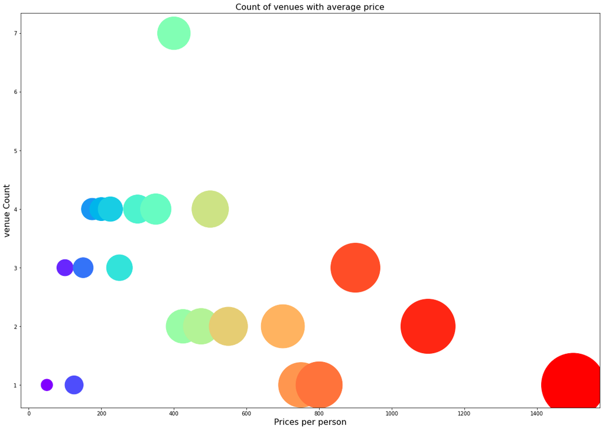

```python
average_prices = selected_venues['average_price'].value_counts().sort_index()
plt.figure(figsize = (20,14))
plt.scatter(average_prices.index,average_prices.values,s= average_prices.index*10, color = cm.rainbow(np.linspace(0,1,len(average_prices.index))))
plt.xlabel("Prices per person",fontsize = 16)
plt.ylabel("venue Count",fontsize = 16)
plt.title('Count of venues with average price',fontsize=16)
```

From the above Scatter plot we can observe that **Majority of venues** are in the **Range of 200-400**

Users might also be interested in going to a place that fits the budget also we will plot the price range on the map using colors `red for high average prices` and `dark green for very low average prices`.

```python
## Plotting venues on Map
color_map = {'4.0':'red','3.0':'orange','2.0':'green','1.0':'darkgreen'}

hyd_map = folium.Map(location = [Hyd_latitude,Hyd_longitude],zoom_start =10)

for name,adddress, latitude,longitude,price_range  in zip(selected_venues['venue'],selected_venues['address'],selected_venues['latitude'],selected_venues['longitude'],selected_venues['price_range'].astype(str)):
    label = '{},{}'.format(name,address)
    label = folium.Popup(label,parse_html = True)
    folium.Marker(
                  [latitude,longitude],
                  icon = folium.Icon(color = color_map[price_range]),
                  popup=label,
                  ).add_to(hyd_map)
hyd_map.save("Venues_prices.html")
hyd_map
```

[interactive chart not shown]

1) Near **Begumpet,Neckalce Road and Near Lv Prasad eye hospital Road no 3** we have restaurants with very high average price.

2) Near Ameerpet with in 4km radius we can observe that they are many restaurants with price range of 200-600 which are budget friendly prices.

3) Near Punjagutta we can observe a lot of restaurants with low average prices

## Clustering

We will cluster all the venues based on all the available features like pricerange ,rating etc.., to identify similar venues and relationship among them.

In this case we will consider dividing into 2 groups.

```python
from sklearn.cluster import KMeans

num_of_clusters = 2
clustering = selected_venues.drop(['venue','address','rating_bin','categories'],1)
kMeans = KMeans(n_clusters= num_of_clusters,random_state = 0).fit(clustering)
selected_venues.insert(0,'clusters_labels',kMeans.labels_)
selected_venues.head(5)
```

|  | clusters_labels | categories | venue | latitude | longitude | price_range | rating | address | average_price | rating_bin |
| --- | --- | --- | --- | --- | --- | --- | --- | --- | --- | --- |
| 0 | 0 | Diner | Hyderabad Street Kitchen | 17.4335 | 78.4469 | 2.0 | 3.2 | 6-3-793, Officers Colony, Punjagutta, Kakatiya... | 350.0 | Good |
| 1 | 1 | Pub | 10 Downing Street | 17.4359 | 78.4574 | 3.0 | 4.1 | 10, Ground Floor, My Home Tycoon, Begumpet, Hy... | 900.0 | Very Good |
| 2 | 0 | Ice Cream Shop | Natural Ice Cream | 17.4286 | 78.4396 | 1.0 | 4.6 | G 3, Raghavendra Grand Residency, Opposite Rat... | 100.0 | Very Good |
| 3 | 0 | Indian Restaurant | Minerva Coffee Shop | 17.4288 | 78.4560 | 2.0 | 3.9 | Ground Floor, Amrutha Mall, Opposite GRT Jewel... | 400.0 | Good |
| 4 | 1 | Hotel | The Grill - Vivanta By Taj | 17.4437 | 78.4609 | 4.0 | 3.9 | Vivanta By Taj, 1-10-147 & 148, Mayuri Marg, B... | 1100.0 | Good |

```python
# on Map

hyd_map = folium.Map(location = [Hyd_latitude,Hyd_longitude],zoom_start =10)
color_map = {0:'green',1:'red'}


# add venues to map

markers_colors = []


for  venue,address,cluster,latitude,longitude in zip(selected_venues['venue'],selected_venues['address'],selected_venues['clusters_labels'],selected_venues['latitude'],selected_venues['longitude']):

    label = folium.Popup(str(venue) + ',' + str(address),parse_html = True)
    folium.CircleMarker([latitude,longitude],
                                radius = 5,
                                popup = label,
                                color = color_map[cluster],
                                fill = True,
                                fill_color = color_map[cluster],
                                fill_opacity = 0.7
                               ).add_to(hyd_map)


for index,cluster in enumerate(kMeans.cluster_centers_):
    latitude = cluster[0]
    longitude = cluster[1]
    label = folium.Popup("Cluster : " + str(index),parse_html = True)
    folium.CircleMarker(
                        [latitude,longitude],
                        radius = 10,
                        popup=label,
                        color =  color_map[index],
                        fill=True,
                        fill_color = color_map[index],
                        fill_opacity = 0.7,
                        ).add_to(hyd_map)


hyd_map.save("Venues_Clusters.html")
hyd_map
```

[interactive chart not shown]

```python
result = selected_venues[selected_venues['clusters_labels']==0]
print("Cluster 0")
result.head(10).reset_index(drop=True)
```

```
Cluster 0
```

|  | clusters_labels | categories | venue | latitude | longitude | price_range | rating | address | average_price | rating_bin |
| --- | --- | --- | --- | --- | --- | --- | --- | --- | --- | --- |
| 0 | 0 | Diner | Hyderabad Street Kitchen | 17.4335 | 78.4469 | 2.0 | 3.2 | 6-3-793, Officers Colony, Punjagutta, Kakatiya... | 350.0 | Good |
| 1 | 0 | Ice Cream Shop | Natural Ice Cream | 17.4286 | 78.4396 | 1.0 | 4.6 | G 3, Raghavendra Grand Residency, Opposite Rat... | 100.0 | Very Good |
| 2 | 0 | Indian Restaurant | Minerva Coffee Shop | 17.4288 | 78.4560 | 2.0 | 3.9 | Ground Floor, Amrutha Mall, Opposite GRT Jewel... | 400.0 | Good |
| 3 | 0 | Fast Food Restaurant | Meridian Cafe & Restaurant | 17.4274 | 78.4523 | 2.0 | 4.5 | 6-3-697/1, Officers Colony, Panjagutta Cross R... | 300.0 | Very Good |
| 4 | 0 | Performing Arts Venue | Lamakaan | 17.4212 | 78.4473 | 1.0 | 4.6 | Near GVK One, Road 5, Banjara Hills, Hyderabad | 100.0 | Very Good |
| 5 | 0 | South Indian Restaurant | Southern Mirchi | 17.4264 | 78.4486 | 2.0 | 3.7 | Plot 76, Nagarjuna Hills, Panjagutta, Hyderabad | 400.0 | Good |
| 6 | 0 | Indian Restaurant | Kritunga Restaurant | 17.4381 | 78.4428 | 2.0 | 3.8 | 8-3-214/2/41, Opposite Maitrivanam, West Srini... | 350.0 | Good |
| 7 | 0 | Asian Restaurant | Chinese Pavilion | 17.4235 | 78.4488 | 3.0 | 4.2 | Vengal Rao Park, Road 1, Banjara Hills, Hyderabad | 500.0 | Very Good |
| 8 | 0 | Bakery | Big Byte | 17.4302 | 78.4384 | 1.0 | 4.0 | 8-3-978/3, Road 1, Dwarakapuri, Srinagar Colon... | 225.0 | Good |
| 9 | 0 | Indian Restaurant | Blue Fox | 17.4375 | 78.4460 | 3.0 | 3.6 | Plot No 3, Regency Plaza, Behind HUDA Mythriva... | 500.0 | Good |

```python
print(result['price_range'].mean(),result['rating'].astype(float).mean())
```

```
1.7083333333333333 3.854166666666666
```

```python
result = selected_venues[selected_venues['clusters_labels']==1]
print("Cluster 1")
result.head(10).reset_index(drop=True)
```

```
Cluster 1
```

|  | clusters_labels | categories | venue | latitude | longitude | price_range | rating | address | average_price | rating_bin |
| --- | --- | --- | --- | --- | --- | --- | --- | --- | --- | --- |
| 0 | 1 | Pub | 10 Downing Street | 17.4359 | 78.4574 | 3.0 | 4.1 | 10, Ground Floor, My Home Tycoon, Begumpet, Hy... | 900.0 | Very Good |
| 1 | 1 | Hotel | The Grill - Vivanta By Taj | 17.4437 | 78.4609 | 4.0 | 3.9 | Vivanta By Taj, 1-10-147 & 148, Mayuri Marg, B... | 1100.0 | Good |
| 2 | 1 | Hotel | Tulips - Hotel GreenPark | 17.4359 | 78.4539 | 3.0 | 3.9 | Hotel Green Park, Begumpet, Hyderabad | 700.0 | Good |
| 3 | 1 | Indian Restaurant | Journey 1853 | 17.4152 | 78.4489 | 3.0 | 4.2 | 5th Floor, City Center Mall, Road 1, Banjara H... | 900.0 | Very Good |
| 4 | 1 | Nightclub | Kismet - The Park | 17.4231 | 78.4627 | 4.0 | 4.2 | The Park Hotel, 22, 1st Floor, Raj Bhavan Road... | 1500.0 | Very Good |
| 5 | 1 | Nightclub | Karma Unplugged Bar | 17.4256 | 78.4203 | 3.0 | 4.2 | 8th Floor, Shangri La Towers, Road 2, Banjara ... | 750.0 | Very Good |
| 6 | 1 | Indian Restaurant | Exotica | 17.4103 | 78.4372 | 3.0 | 4.6 | 5th Floor, 12th Square Building, Road 12, Oppo... | 900.0 | Very Good |
| 7 | 1 | American Restaurant | TGI Fridays | 17.4235 | 78.4279 | 4.0 | 4.1 | 1st Floor, Cinemax Building, RK Cineplex, Oppo... | 1100.0 | Very Good |
| 8 | 1 | Bengali Restaurant | Oh! Calcutta | 17.4315 | 78.4565 | 3.0 | 4.4 | 6-3-1186/1/1, Greenlands Road, Opposite CM Res... | 800.0 | Very Good |
| 9 | 1 | Asian Restaurant | Blue Fox | 17.4234 | 78.4278 | 3.0 | 3.9 | 1st Floor, Cinemax Building, RK Cineplex, Road... | 700.0 | Good |

```python
print(result['price_range'].mean(),result['rating'].astype(float).mean())
```

```
3.3 4.15
```

## Results and Discussion

Based on our analysis above we can get some conclusions which can be useful for any visitor visiting hyderabad(Ameerpet) India.

BY analysing all the venues we observed that **majority of venues are Indian Restaurants Fast food centers and Bakery** A visitor who is searching for items fried fast food items like fried rice or noodles can get food easily and also we have many indian Restaurants here.

The **majority of venues are with rating of 4** which means that majority of restaurants are providing good quality of food. We also observed that there are cluster of venues in Road no.3 banjara hills, Begumpet, and Road no.1 Banjara hills near punjagutta with ratings which are Good.

**Based on the price range there are many restaurants with average price range of 200-400** in the city. Also the price range varies from 100 - 3000. on plotting the map of this venues we observed costlier venues in Begumpet,Neckalce Road and Near Lv Prasad eye hospital Road no 3. Near punjagutta we can observe many restaurants with low prices.

Finally from the clusters we **identified venues** which are with **relatively low prices and average rating og 3.85**.Also few venues which are **too expensive but have a good rating of 4.15**

## Conclusion

The purpose of this project is to explore restaurants near Ameerpet for the people who are visiting hyderabad. Also to taste good food.The venues have been identified using Foursquare and Zomato API and have been plotted on the map. The map reveals that there are three major areas a person can visit: `Road no.3 banjara hills, Begumpet, and Road no.1 Banjara hills near punjagutta`.

[output not shown]